# Assignment7_MinHashLSH_JaccardSimilarity_Title

# Clean the data, remove stopwords and create index

# Tokenize the text column and remove stopwords

```python
# Add an 'id' column to df: the IDs are not necessarily consecutive but are guaranteed to be unique across the entire DataFrame.
df_text = df_text.withColumn("id", monotonically_increasing_id())

# Split text into words
df_text = df_text.withColumn("words", split(col("text"), " "))

# Remove punctuation and split into words
# \p{P} matches any kind of punctuation character
# \p{C} matches any kind of control character
df_text = df_text.withColumn("clean_text", F.regexp_replace(F.col("text"), "[\p{P}\p{C}]", ""))
df_text = df_text.withColumn("words", split(F.col("clean_text"), " "))

# Filter out tokens that are less than 3 characters
df_text = df_text.withColumn("clean_words", F.expr("filter(words, word -> length(word) > 1)"))

# Remove stopwords
remover = StopWordsRemover(inputCol="clean_words", outputCol="filtered_words")
df_text = remover.transform(df_text)

display(df_text.select('id',
                       'text',
                       'clean_text',
                       'words',
                       'clean_words',
                       'filtered_words').limit(5).toPandas())

# Keep only the variables we need
df_text = df_text.select('id','text','filtered_words')
```

|  | id | text | clean_text | words | clean_words | filtered_words |
| --- | --- | --- | --- | --- | --- | --- |
| 0 | 0 | Local police on alert in wake of alleged ‘TikTok’ school violence campaign \| Reading \| homenewshere.com | Local police on alert in wake of alleged TikTok school violence campaign \| Reading \| homenewsherecom | [Local, police, on, alert, in, wake, of, alleged, , TikTok, school, violence, campaign, \|, Reading, \|, homenewsherecom] | [Local, police, on, alert, in, wake, of, alleged, TikTok, school, violence, campaign, Reading, homenewsherecom] | [Local, police, alert, wake, alleged, TikTok, school, violence, campaign, Reading, homenewsherecom] |
| 1 | 1 | Biden Revokes Trump's Ban On Chinese Apps TikTok, WeChat; Orders 'Criteria-Based Decision' \| Indian Defence News | Biden Revokes Trumps Ban On Chinese Apps TikTok WeChat Orders CriteriaBased Decision \| Indian Defence News | [, Biden, Revokes, Trumps, Ban, On, Chinese, Apps, TikTok, WeChat, Orders, CriteriaBased, Decision, \|, Indian, Defence, News, ] | [Biden, Revokes, Trumps, Ban, On, Chinese, Apps, TikTok, WeChat, Orders, CriteriaBased, Decision, Indian, Defence, News] | [Biden, Revokes, Trumps, Ban, Chinese, Apps, TikTok, WeChat, Orders, CriteriaBased, Decision, Indian, Defence, News] |
| 2 | 2 | Woolworths supermarket worker ‘loses his mind’ over bizarre ‘wheel’ discovery in new viral TikTok video \| 7NEWS | Woolworths supermarket worker loses his mind over bizarre wheel discovery in new viral TikTok video \| 7NEWS | [Woolworths, supermarket, worker, loses, his, mind, over, bizarre, wheel, discovery, in, new, viral, TikTok, video, \|, 7NEWS] | [Woolworths, supermarket, worker, loses, his, mind, over, bizarre, wheel, discovery, in, new, viral, TikTok, video, 7NEWS] | [Woolworths, supermarket, worker, loses, mind, bizarre, wheel, discovery, new, viral, TikTok, video, 7NEWS] |
| 3 | 3 | Boy, 12, dies two weeks after attempting dangerous ‘Blackout Challenge’ on TikTok \| 7NEWS.com.au | Boy 12 dies two weeks after attempting dangerous Blackout Challenge on TikTok \| 7NEWScomau | [Boy, 12, dies, two, weeks, after, attempting, dangerous, Blackout, Challenge, on, TikTok, \|, 7NEWScomau] | [Boy, 12, dies, two, weeks, after, attempting, dangerous, Blackout, Challenge, on, TikTok, 7NEWScomau] | [Boy, 12, dies, two, weeks, attempting, dangerous, Blackout, Challenge, TikTok, 7NEWScomau] |
| 4 | 4 | TikTok Planning to Move Into the E-Commerce Business – 92.3 WIL | TikTok Planning to Move Into the ECommerce Business 923 WIL | [TikTok Planning, to, Move, Into, the, ECommerce, Business, , 923, WIL] | [TikTok Planning, to, Move, Into, the, ECommerce, Business, 923, WIL] | [TikTok Planning, Move, ECommerce, Business, 923, WIL] |

```python
df_text.limit(2).toPandas()
```

[output not shown]

# Fit countvectorizer to create word features

```python
vectorize = CountVectorizer(inputCol="filtered_words", outputCol="features", minDF=1.0)
df_vectorize = vectorize.fit(df_text).transform(df_text)

display(df_vectorize.limit(5).toPandas())
```

[output not shown]

# Fit MinHashLSH to create hash table

# These code snippets apply MinHashLSH to hash the feature vectors generated by CountVectorizer, allowing for efficient similarity search and nearest neighbor retrieval in high-dimensional vector spaces, especially useful for large-scale datasets where exact similarity search might be computationally expensive.

```python
mh = MinHashLSH(inputCol="features", outputCol="hashes", numHashTables=5)
model = mh.fit(df_vectorize)
df_hashed_text = mh.fit(df_vectorize).transform(df_vectorize).cache()

display(df_hashed_text.limit(5).toPandas())
```

|  | id | text | filtered_words | features | hashes |
| --- | --- | --- | --- | --- | --- |
| 0 | 0 | Local police on alert in wake of alleged ‘TikTok’ school violence campaign \| Reading \| homenewshere.com | [Local, police, alert, wake, alleged, TikTok, school, violence, campaign, Reading, homenewsherecom] | (1.0, 0.0, 0.0, 0.0, 0.0, 0.0, 0.0, 0.0, 0.0, 0.0, 0.0, 0.0, 0.0, 0.0, 0.0, 0.0, 0.0, 0.0, 0.0, 0.0, 0.0, 0.0, 0.0, 0.0, 0.0, 0.0, 0.0, 0.0, 0.0, 0.0, 0.0, 0.0, 0.0, 0.0, 0.0, 0.0, 0.0, 0.0, 0.0, 0.0,… | [[47945584.0], [138227756.0], [681870974.0], [11786245.0], [64833408.0]] |
| 1 | 1 | Biden Revokes Trump's Ban On Chinese Apps TikTok, WeChat; Orders 'Criteria-Based Decision' \| Indian Defence News | [Biden, Revokes, Trumps, Ban, Chinese, Apps, TikTok, WeChat, Orders, CriteriaBased, Decision, Indian, Defence, News] | (1.0, 1.0, 0.0, 0.0, 0.0, 0.0, 0.0, 0.0, 0.0, 0.0, 0.0, 0.0, 0.0, 0.0, 0.0, 0.0, 0.0, 0.0, 0.0, 0.0, 0.0, 0.0, 0.0, 0.0, 0.0, 0.0, 0.0, 0.0, 0.0, 0.0, 0.0, 0.0, 0.0, 0.0, 0.0, 0.0, 0.0, 0.0, 1.0, 0.0,… | [[29276036.0], [116306618.0], [86290611.0], [273146236.0], [207259394.0]] |
| 2 | 2 | Woolworths supermarket worker ‘loses his mind’ over bizarre ‘wheel’ discovery in new viral TikTok video \| 7NEWS | [Woolworths, supermarket, worker, loses, mind, bizarre, wheel, discovery, new, viral, TikTok, video, 7NEWS] | (1.0, 0.0, 1.0, 0.0, 1.0, 0.0, 0.0, 0.0, 0.0, 0.0, 0.0, 0.0, 0.0, 0.0, 0.0, 1.0, 0.0, 0.0, 0.0, 0.0, 0.0, 0.0, 0.0, 0.0, 0.0, 0.0, 0.0, 0.0, 0.0, 0.0, 0.0, 0.0, 0.0, 0.0, 0.0, 0.0, 0.0, 0.0, 0.0, 0.0,… | [[47945584.0], [359178980.0], [30854182.0], [92690373.0], [177713239.0]] |
| 3 | 3 | Boy, 12, dies two weeks after attempting dangerous ‘Blackout Challenge’ on TikTok \| 7NEWS.com.au | [Boy, 12, dies, two, weeks, attempting, dangerous, Blackout, Challenge, TikTok, 7NEWScomau] | (1.0, 0.0, 0.0, 0.0, 0.0, 0.0, 0.0, 0.0, 0.0, 0.0, 0.0, 0.0, 0.0, 0.0, 0.0, 0.0, 0.0, 0.0, 0.0, 0.0, 0.0, 0.0, 0.0, 0.0, 0.0, 0.0, 0.0, 0.0, 0.0, 0.0, 0.0, 1.0, 0.0, 0.0, 0.0, 0.0, 0.0, 0.0, 0.0, 0.0,… | [[47945584.0], [433291930.0], [203800912.0], [461219945.0], [36698536.0]] |
| 4 | 4 | TikTok Planning to Move Into the E-Commerce Business – 92.3 WIL | [TikTok Planning, Move, ECommerce, Business, 923, WIL] | (0.0, 0.0, 0.0, 0.0, 0.0, 0.0, 0.0, 0.0, 0.0, 0.0, 0.0, 0.0, 0.0, 0.0, 0.0, 0.0, 0.0, 0.0, 0.0, 0.0, 0.0, 0.0, 0.0, 0.0, 0.0, 0.0, 0.0, 0.0, 0.0, 0.0, 0.0, 0.0, 0.0, 0.0, 0.0, 0.0, 0.0, 0.0, 0.0, 0.0,… | [[64620604.0], [128708708.0], [355048392.0], [39718347.0], [70830672.0]] |

# Step 4. Establish similarity threshold and return near-duplicate records

# **Note:** we are joining dataframe to itself to get near-duplicate pairs

Also note: you do not join on specific variables like keys or IDs. Instead, you join based on the similarity of feature vectors, which is determined using LSH algorithms.

These code use the MinHashLSH model to find pairs of documents with Jaccard similarities above a specified threshold (jaccard_distance). The resulting DataFrame (df_dups_text) contains pairs of similar documents along with their Jaccard distances and text content.

# a Jaccard distance of 0.3 means that pairs of sets with a Jaccard similarity (1 - Jaccard distance) greater than or equal to 0.7 will be considered similar.

```python
jaccard_distance = 0.3

df_dups_text = model.approxSimilarityJoin(df_hashed_text, df_hashed_text, jaccard_distance).filter("datasetA.id < datasetB.id").select(
            col("distCol"),
            col("datasetA.id").alias("id_A"),
            col("datasetB.id").alias("id_B"),
            col('datasetA.text').alias('text_A'),
            col('datasetB.text').alias('text_B'),
#             col('datasetA.list_of_words').alias('words_A'),
#             col('datasetB.list_of_words').alias('words_B')
            )
```

```python
%%time

df_dups_30 = df_dups_text
df_dups_text.cache()
df_dups_text.limit(5).toPandas()
```

```
[Stage 30:>                                                         (0 + 1) / 1]
```

```
CPU times: user 12.5 ms, sys: 12.3 ms, total: 24.8 ms
Wall time: 23.8 s
```

|  | distCol | id_A | id_B | text_A | text_B |
| --- | --- | --- | --- | --- | --- |
| 0 | 0.125000 | 44 | 3759 | Pot-bellied Japanese security guards reach TikTok stardom - KRDO | Pot-bellied Japanese security guards reach TikTok stardom |
| 1 | 0.125000 | 44 | 3451 | Pot-bellied Japanese security guards reach TikTok stardom - KRDO | Pot-bellied Japanese security guards reach TikTok stardom |
| 2 | 0.125000 | 44 | 3121 | Pot-bellied Japanese security guards reach TikTok stardom - KRDO | Pot-bellied Japanese security guards reach TikTok stardom |
| 3 | 0.125000 | 44 | 1304 | Pot-bellied Japanese security guards reach TikTok stardom - KRDO | Pot-bellied Japanese security guards reach TikTok stardom |
| 4 | 0.142857 | 63 | 4229 | Italy: Teen in hijab aims to be ‘Afro-influencer’ on TikTok | Italy: Teen in hijab aims to be ‘Afro-influencer’ on TikTok \| ArkLaTexHomepage |

```python
records = df_hashed_text.count()
dups = df_dups_text.select('id_A').distinct().count()
uniques = records - dups

print ('Total records: ', records)
print ('Duplicate titles based on {', jaccard_distance, '} jaccard distance: ', dups)
print ('Unique titles based on {', jaccard_distance, '} jaccard distance: ', jaccard_distance, ': ', uniques)
```

```
Total records:  5000
Duplicate titles based on { 0.3 } jaccard distance:  605
Unique titles based on { 0.3 } jaccard distance:  0.3 :  4395
```

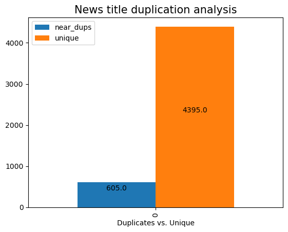

```python
dups_df = pd.DataFrame.from_dict({'near_dups': [dups], 'unique': [uniques]})

ax=dups_df.plot(kind = 'bar',y=['near_dups', 'unique'], fontsize=10, color=['C0', 'C1'], align='center', width=0.8, xlabel="Duplicates vs. Unique")
ax.set_title('News title duplication analysis', fontsize=15)
for p in ax.patches:
       ax.annotate(format(p.get_height(), '.1f'),
                   (p.get_x() + p.get_width() / 2., p.get_height()/2),
                   ha = 'center', va = 'center',
                   xytext = (0, 9),
                   textcoords = 'offset points')
```

# a Jaccard distance of 0.5 means that pairs of sets with a Jaccard similarity (1 - Jaccard distance) greater than or equal to 0.5 will be considered similar.

```python
jaccard_distance = 0.5

df_dups_text = model.approxSimilarityJoin(df_hashed_text, df_hashed_text, jaccard_distance).filter("datasetA.id < datasetB.id").select(
            col("distCol"),
            col("datasetA.id").alias("id_A"),
            col("datasetB.id").alias("id_B"),
            col('datasetA.text').alias('text_A'),
            col('datasetB.text').alias('text_B'),
#             col('datasetA.list_of_words').alias('words_A'),
#             col('datasetB.list_of_words').alias('words_B')
            )
```

```python
%%time

df_dups_50 = df_dups_text
df_dups_text.cache()
df_dups_text.limit(5).toPandas()
```

```
[Stage 38:>                                                         (0 + 1) / 1]
```

```
CPU times: user 17.5 ms, sys: 5.28 ms, total: 22.8 ms
Wall time: 22.8 s
```

|  | distCol | id_A | id_B | text_A | text_B |
| --- | --- | --- | --- | --- | --- |
| 0 | 0.333333 | 20 | 1576 | The domain name tiktokglobalshop.top is for sale \| Dan.com | The domain name tiktoktrendbuy.com is for sale \| Dan.com |
| 1 | 0.333333 | 20 | 1050 | The domain name tiktokglobalshop.top is for sale \| Dan.com | The domain name tiktokko.com is for sale \| Dan.com |
| 2 | 0.333333 | 20 | 537 | The domain name tiktokglobalshop.top is for sale \| Dan.com | The domain name tiktokgood.com is for sale \| Dan.com |
| 3 | 0.454545 | 22 | 2567 | TikTok star Hareem Shah's new video goes viral | TikTok star Jannat Mirza’s new dance video goes viral |
| 4 | 0.454545 | 22 | 2027 | TikTok star Hareem Shah's new video goes viral | TikToker Hareem Shah's new PDA-packed video with husband goes viral |

```python
records = df_hashed_text.count()
dups = df_dups_text.select('id_A').distinct().count()
uniques = records - dups

print ('Total records: ', records)
print ('Duplicate titles based on {', jaccard_distance, '} jaccard distance: ', dups)
print ('Unique titles based on {', jaccard_distance, '} jaccard distance: ', jaccard_distance, ': ', uniques)
```

```
Total records:  5000
Duplicate titles based on { 0.5 } jaccard distance:  1020
Unique titles based on { 0.5 } jaccard distance:  0.5 :  3980
```

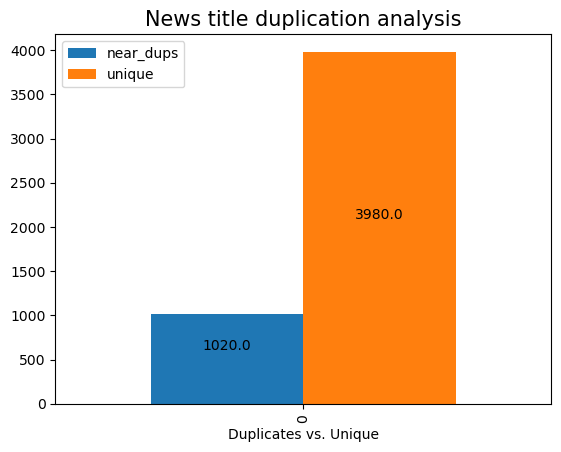

```python
dups_df = pd.DataFrame.from_dict({'near_dups': [dups], 'unique': [uniques]})

ax=dups_df.plot(kind = 'bar',y=['near_dups', 'unique'], fontsize=10, color=['C0', 'C1'], align='center', width=0.8, xlabel="Duplicates vs. Unique")
ax.set_title('News title duplication analysis', fontsize=15)
for p in ax.patches:
       ax.annotate(format(p.get_height(), '.1f'),
                   (p.get_x() + p.get_width() / 2., p.get_height()/2),
                   ha = 'center', va = 'center',
                   xytext = (0, 9),
                   textcoords = 'offset points')
```

# a Jaccard distance of 0.7 means that pairs of sets with a Jaccard similarity (1 - Jaccard distance) greater than or equal to 0.3 will be considered similar.

```python
jaccard_distance = 0.7

df_dups_text = model.approxSimilarityJoin(df_hashed_text, df_hashed_text, jaccard_distance).filter("datasetA.id < datasetB.id").select(
            col("distCol"),
            col("datasetA.id").alias("id_A"),
            col("datasetB.id").alias("id_B"),
            col('datasetA.text').alias('text_A'),
            col('datasetB.text').alias('text_B'),
#             col('datasetA.list_of_words').alias('words_A'),
#             col('datasetB.list_of_words').alias('words_B')
            )
```

```python
%%time

df_dups_70 = df_dups_text
df_dups_text.cache()
df_dups_text.limit(5).toPandas()
```

```
[Stage 46:>                                                         (0 + 1) / 1]
```

```
CPU times: user 17.4 ms, sys: 5.34 ms, total: 22.8 ms
Wall time: 22.4 s
```

|  | distCol | id_A | id_B | text_A | text_B |
| --- | --- | --- | --- | --- | --- |
| 0 | 0.615385 | 3 | 2678 | Boy, 12, dies two weeks after attempting dangerous ‘Blackout Challenge’ on TikTok \| 7NEWS.com.au | Temple girl dies while attempting TikTok 'Blackout Challenge' |
| 1 | 0.666667 | 6 | 1485 | TikTok trend: Eating frozen honey and risking ill effects \| bdnews24.com | How to make frozen honey, the viral TikTok trend - TODAY |
| 2 | 0.625000 | 8 | 4910 | Wendy Williams’ Callous Report Of TikTok Star Swavy’s Death Sparks Chaos \| Bossip | Wendy Williams Slammed for ‘Hateful’ Segment on TikTok Star Swavy’s Death [Video] \| lovebscott.com |
| 3 | 0.666667 | 9 | 4135 | tiktok: Kia, Hyundai sued in US after TikTok challenge triggered car thefts, Marketing & Advertising News, ET BrandEquity | TikTok effects: U.S. states probing TikTok's effects on young people, Marketing & Advertising News, ET BrandEquity |
| 4 | 0.684211 | 9 | 2554 | tiktok: Kia, Hyundai sued in US after TikTok challenge triggered car thefts, Marketing & Advertising News, ET BrandEquity | EU moves against TikTok over child-targeted ads, Marketing & Advertising News, ET BrandEquity |

```python
records = df_hashed_text.count()
dups = df_dups_text.select('id_A').distinct().count()
uniques = records - dups

print ('Total records: ', records)
print ('Duplicate titles based on {', jaccard_distance, '} jaccard distance: ', dups)
print ('Unique titles based on {', jaccard_distance, '} jaccard distance: ', jaccard_distance, ': ', uniques)
```

```
Total records:  5000
Duplicate titles based on { 0.7 } jaccard distance:  1456
Unique titles based on { 0.7 } jaccard distance:  0.7 :  3544
```

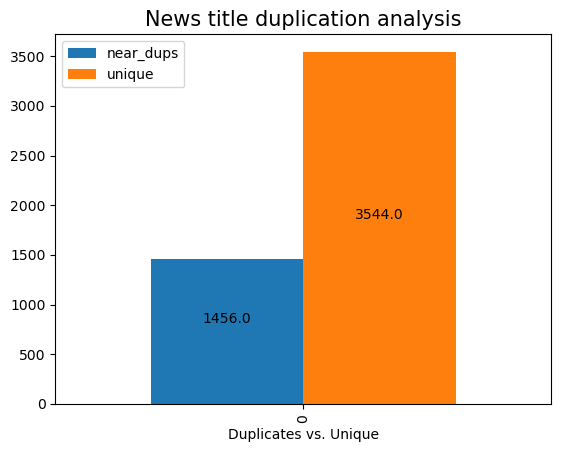

```python
dups_df = pd.DataFrame.from_dict({'near_dups': [dups], 'unique': [uniques]})

ax=dups_df.plot(kind = 'bar',y=['near_dups', 'unique'], fontsize=10, color=['C0', 'C1'], align='center', width=0.8, xlabel="Duplicates vs. Unique")
ax.set_title('News title duplication analysis', fontsize=15)
for p in ax.patches:
       ax.annotate(format(p.get_height(), '.1f'),
                   (p.get_x() + p.get_width() / 2., p.get_height()/2),
                   ha = 'center', va = 'center',
                   xytext = (0, 9),
                   textcoords = 'offset points')
```

# Compare thresholds side-by-side

# Select all pairs of duplicate titles across jaccard similarities

```python
df_dups_30_id = df_dups_30.select(col('id_A').alias('id_30_A'), col('id_B').alias('id_30_B'))
df_dups_50_id = df_dups_50.select(col('id_A').alias('id_50_A'), col('id_B').alias('id_50_B'))
df_dups_70_id = df_dups_70.select(col('text_A'), col('text_B'),\
                                  col('id_A').alias('id_70_A'), col('id_B').alias('id_70_B'))

print(df_dups_30_id.count())
print(df_dups_50_id.count())
print(df_dups_70_id.count())
```

```
1232
23411
24786
```

```python
# Less the dups the better.
# the threshold of 0.3 is the most reasonable choice, fewer duplicates are generally the more desired outcome.
# a Jaccard distance of 0.3 means that pairs of sets with a **Jaccard similarity (1 - Jaccard distance) greater than or equal to 0.7 will be considered similar.**
# We can use either text or titles for the “near-duplicate” detection mechanism, the results are very similar.
# However, the shortness of titles means a much less computationally taxing approch.

# Recommendation
```

[output not shown]

```python
data = [df_dups_30_id.count(), df_dups_50_id.count(), df_dups_70_id.count()]
data
```

```
[1232, 23411, 24786]
```

# Build a histogram showing the overall distribution of “near-duplication”

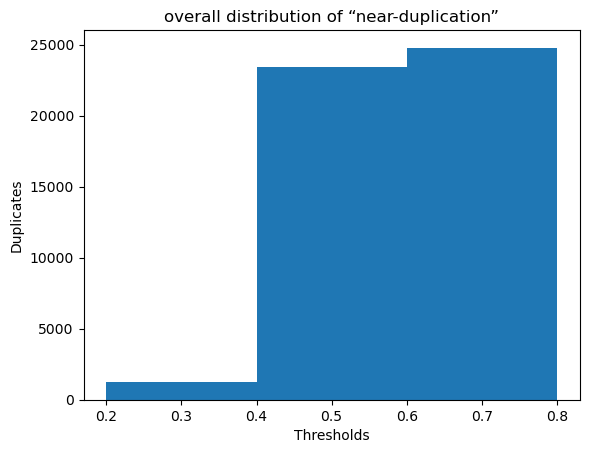

```python
import matplotlib.pyplot as plt

bin_edges = [ 0.3, 0.5, 0.7]
bin_labels = ['0.3', '0.5', '0.7']

plt.bar(bin_edges, data, width = 0.2)
#bin_midpoints = [(bin_edges[i] + bin_edges[i+1])/2 for i in range(len(bin_edges)-1)]
#plt.xticks(bin_midpoints, bin_labels)
plt.xlabel('Thresholds')
plt.ylabel('Duplicates')
plt.title('overall distribution of “near-duplication”')
plt.show()
```